# Week2: Data objects and loading/saving files in R/RStudio

# Week2: Data objects and loading/saving files in R/RStudio

# How to store data in R

An object in R is a placeholder for different **types** of data and functions created or manipulated in R. The following sections focus on data **types** and then on data **objects**.

## Data types

R objects can store values as different data types including numeric, character, logical or date. R variable types are often referred to as **modes** and can be identified using the `mode()` function.

### Numeric

The numerical data type is probably the simplest. It consists of numbers such as integers (e.g. `1 ,-3 ,33 ,0`) or doubles (e.g. `0.3, 12.4, -0.04, 1.0`). For example, to create a numeric (double) vector we can type:

```r
x <- c(1.0, -3.4, 2, 140.1)
mode(x)
```

```
## [1] "numeric"
```

### Character

The character data type consists of letters or words such as `"a", "f", "project", "house value"`.

```r
x <- c("a", "f", "project", "house value")
mode(x)
```

```
## [1] "character"
```

Characters can also consist of numbers represented as characters. The distinction between a numeric representation of a number and a numeric one is important. For example, if we have two numeric vector `x` and `y` such as

```r
x <- 3
y <- 5.3
```

and we choose to sum the two variables, we get:

```r
x + y
```

```
## [1] 8.3
```

If we repeat these steps but instead choose to represent the numbers `3` and `5.3` as characters we get the following error message:

```r
x <- "3"
y <- "5.3"
x + y
```

```
## Error in x + y: non-numeric argument to binary operator
```

Note that if numbers are to be stored as characters, don’t forget to wrap them around quotes.

```r
x <- c("1.0", "-3.4", "2", "140.1")
mode(x)
```

```
## [1] "character"
```

### Logical

Logical values can take on one of two values: `TRUE` or `FALSE`. These can also be represented as `1` or `0`. For example, to create a logical vector of 4 elements, you can type

```r
x <- c(TRUE, FALSE, FALSE, TRUE)
```

or

```r
x <- as.logical(c(1,0,0,1))
```

Note that in both cases, `mode(x)` returns logical. Also note that the `1`’s and `0`’s are converted to `TRUE`’s and `FALSE`’s.

### Factors

Factors are usually used to group variables into categories having a fixed number of levels. For example, a dataset may be grouped by gender or month of the year. Such data may be loaded into R as a numeric or character data type in which case it needs to be converted to a factor using the `as.factor()` function.

```r
a      <- c("M", "F", "F", "M", "F", "M", "M", "F", "F", "M")
a.fact <- as.factor(a)
x      <- c(166, 47, 61, 148, 62, 123, 232, 98, 93, 55)
dat    <- data.frame(x = x, gender = a.fact)
```

Many functions recognize factor data types and will allow you to split the output into groups. For example, to create a boxplot of the value `x` split into two groups, `F` and `M`, you can type the following:

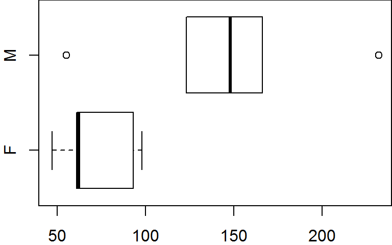

```r
boxplot(x ~ gender, dat, horizontal = TRUE)
```

## Data structure

### Vectors

Vector objects can be broken down into two types: atomic vector and lists.

### Atomic vectors

```r
x <- c(674 , 4186 , 5308 , 5083 , 6140 , 6381)
x
```

```
## [1]  674 4186 5308 5083 6140 6381
```

A vector object is an indexable collection of values and can thus allow one to access a specific index number. For example, to access the third element of `x`, type

```r
x[3]
```

```
## [1] 5308
```

You can also select a subset of elements by index values using the combine function `c()`,

```r
x[c(1,3,4)]
```

```
## [1]  674 5308 5083
```

If you are interested in a range of indexed values, use `:`

```r
x[2:4]
```

```
## [1] 4186 5308 5083
```

You can also assign new values to a specific index. For example, we can replace the second value with 0

```r
x[2] <- 0
x
```

```
## [1]  674    0 5308 5083 6140 6381
```

Note that a vector can also store characters or strings

```r
x <- c("all", "b", "olive")
x
```

```
## [1] "all"   "b"     "olive"
```

### Lists

Like atomic vectors, a list is an ordered set of elements but unlike vectors, elements of a list can be of any type. A list is constructed using the `list()` function.

For example, the following list consists of 3 elements: a three element numeric vector(element `a`), a two element logical vector (element `b`) and a three element character vector (element `c`).

```r
l <- list(a = c(123.1, 3, 87.6), b = c(TRUE, FALSE), c = c("apples", "oranges", "round"))
```

You can view the contents of a list using the `str()` function.

```r
str(l)
```

```
## List of 3
##  $ a: num [1:3] 123.1 3 87.6
##  $ b: logi [1:2] TRUE FALSE
##  $ c: chr [1:3] "apples" "oranges" "round"
```

Lists can also be recursive (i.e. a list can contain other lists). For example, the following list `l2` houses two elements: a two-by-two matrix (element `a`) and the list `l` (element `b`).

```r
l2 <- list( a = matrix( c(12.3, 20, 1.2, 18.0) , nrow=2), b = l)
str(l2)
```

```
## List of 2
##  $ a: num [1:2, 1:2] 12.3 20 1.2 18
##  $ b:List of 3
##   ..$ a: num [1:3] 123.1 3 87.6
##   ..$ b: logi [1:2] TRUE FALSE
##   ..$ c: chr [1:3] "apples" "oranges" "round"
```

You’ll find that many functions in R return list objects such as the linear model function `lm`. For example, run a regression between two variables and save the output of the regression analysis to an object called `M`:

```r
x <- c(7.3, 29.4, 29.4, 2.9, 12.3, 7.5, 36.0, 4.8, 18.8, 4.2)
y <- c(5.2, 26.6, 31.2, 2.2, 13.8, 7.8, 35.2, 8.6, 20.3, 1.1)
M <- lm( y ~ x)
```

Now use the `typeof` function to view `M`’s data type:

```r
typeof(M)
```

```
## [1] "list"
```

The contents of the regression model object `M` consists of 12 elements which include various diagnostic statistics, regression coefficients, and residuals.

```r
str(M)
```

```
## List of 12
##  $ coefficients : Named num [1:2] 0.0779 0.991
##   ..- attr(*, "names")= chr [1:2] "(Intercept)" "x"
##  $ residuals    : Named num [1:10] -2.112 -2.612 1.988 -0.752 1.533 ...
##   ..- attr(*, "names")= chr [1:10] "1" "2" "3" "4" ...
##  $ effects      : Named num [1:10] -48.07 -36.54 3.13 -0.66 2 ...
##   ..- attr(*, "names")= chr [1:10] "(Intercept)" "x" "" "" ...
##  $ rank         : int 2
##  $ fitted.values: Named num [1:10] 7.31 29.21 29.21 2.95 12.27 ...
##   ..- attr(*, "names")= chr [1:10] "1" "2" "3" "4" ...
##  $ assign       : int [1:2] 0 1
##  $ qr           :List of 5
##   ..$ qr   : num [1:10, 1:2] -3.162 0.316 0.316 0.316 0.316 ...
##   .. ..- attr(*, "dimnames")=List of 2
##   .. .. ..$ : chr [1:10] "1" "2" "3" "4" ...
##   .. .. ..$ : chr [1:2] "(Intercept)" "x"
##   .. ..- attr(*, "assign")= int [1:2] 0 1
##   ..$ qraux: num [1:2] 1.32 1.44
##   ..$ pivot: int [1:2] 1 2
##   ..$ tol  : num 1e-07
##   ..$ rank : int 2
##   ..- attr(*, "class")= chr "qr"
##  $ df.residual  : int 8
##  $ xlevels      : Named list()
##  $ call         : language lm(formula = y ~ x)
##  $ terms        :Classes 'terms', 'formula' length 3 y ~ x
##   .. ..- attr(*, "variables")= language list(y, x)
##   .. ..- attr(*, "factors")= int [1:2, 1] 0 1
##   .. .. ..- attr(*, "dimnames")=List of 2
##   .. .. .. ..$ : chr [1:2] "y" "x"
##   .. .. .. ..$ : chr "x"
##   .. ..- attr(*, "term.labels")= chr "x"
##   .. ..- attr(*, "order")= int 1
##   .. ..- attr(*, "intercept")= int 1
##   .. ..- attr(*, "response")= int 1
##   .. ..- attr(*, ".Environment")=<environment: R_GlobalEnv>
##   .. ..- attr(*, "predvars")= language list(y, x)
##   .. ..- attr(*, "dataClasses")= Named chr [1:2] "numeric" "numeric"
##   .. .. ..- attr(*, "names")= chr [1:2] "y" "x"
##  $ model        :'data.frame':   10 obs. of  2 variables:
##   ..$ y: num [1:10] 5.2 26.6 31.2 2.2 13.8 7.8 35.2 8.6 20.3 1.1
##   ..$ x: num [1:10] 7.3 29.4 29.4 2.9 12.3 7.5 36 4.8 18.8 4.2
##   ..- attr(*, "terms")=Classes 'terms', 'formula' length 3 y ~ x
##   .. .. ..- attr(*, "variables")= language list(y, x)
##   .. .. ..- attr(*, "factors")= int [1:2, 1] 0 1
##   .. .. .. ..- attr(*, "dimnames")=List of 2
##   .. .. .. .. ..$ : chr [1:2] "y" "x"
##   .. .. .. .. ..$ : chr "x"
##   .. .. ..- attr(*, "term.labels")= chr "x"
##   .. .. ..- attr(*, "order")= int 1
##   .. .. ..- attr(*, "intercept")= int 1
##   .. .. ..- attr(*, "response")= int 1
##   .. .. ..- attr(*, ".Environment")=<environment: R_GlobalEnv>
##   .. .. ..- attr(*, "predvars")= language list(y, x)
##   .. .. ..- attr(*, "dataClasses")= Named chr [1:2] "numeric" "numeric"
##   .. .. .. ..- attr(*, "names")= chr [1:2] "y" "x"
##  - attr(*, "class")= chr "lm"
```

Elements of a list can be extracted using the `$` symbol. For example, to access the values from `M`’s `residuals` element, type

```r
M$residuals
```

```
##          1          2          3          4          5          6
## -2.1119291 -2.6122265  1.9877735 -0.7516888  1.5332525  0.2898782
##          7          8          9         10
## -0.5525869  3.7654802  1.5919885 -3.1399416
```

The element `residual` is a numeric vector. We can also access the contents of a recursive list element such as `qr`:

```r
M$qr
```

```
## $qr
##    (Intercept)            x
## 1   -3.1622777 -48.25635709
## 2    0.3162278 -36.87009628
## 3    0.3162278   0.43537761
## 4    0.3162278  -0.28336204
## 5    0.3162278  -0.02841288
## 6    0.3162278  -0.15859968
## 7    0.3162278   0.61438447
## 8    0.3162278  -0.23182976
## 9    0.3162278   0.14788175
## 10   0.3162278  -0.24810311
## attr(,"assign")
## [1] 0 1
##
## $qraux
## [1] 1.316228 1.435378
##
## $pivot
## [1] 1 2
##
## $tol
## [1] 1e-07
##
## $rank
## [1] 2
##
## attr(,"class")
## [1] "qr"
```

Note that since the element `qr` is a list, `M$qr` returns a list (and not a numeric vector as in the call to `M$residuals`). To extract the element `qraux` from the list `qr` (which is itself an element of `M`), you can use a recursive `$` as in:

```r
M$qr$qraux
```

```
## [1] 1.316228 1.435378
```

Note that in the previous examples, a name was assigned to each element of the list (e.g. `a = matrix( c(12.3, 20, 1.2, 18.0)`) which allows us to access that element using the hash name (e.g. `l2$a`). We can list the element names of a list using the `names()` function:

```r
names(l2)
```

```
## [1] "a" "b"
```

But lists can also be created without assigning names to an element. For example, list `l2` could be created as follows:

```r
l2.nonames <- list( matrix( c(12.3, 20, 1.2, 18.0) , nrow=2), l)
```

This last object has no names associated with its elements,

```r
names(l2.nonames)
```

[output not shown]

This makes it impossible to access its elements using the `$` symbol. We must instead use the `[]` symbol to access the ordered elements. For example, to access the first element of `l2.nonames`, type:

```r
l2.nonames[1]
```

```
## [[1]]
##      [,1] [,2]
## [1,] 12.3  1.2
## [2,] 20.0 18.0
```

This displays the contents of the matrix, but the output is still a list which means that we cannot operate on the content as though it was a matrix (however, had the element been named as with the object `l2`, then the use of the `$` symbol would have returned a matrix as in `l2$a`).